# Using the `sparseR` package

Ryan A. Peterson

2025-04-14

# 1 Introduction

The `sparseR` package aids in the implementation of ranked sparsity methods for model selection in the presence of interactions and polynomials.

The following methods are supported, with help from `ncvreg` on the backend:

1. The sparsity-ranked lasso (SRL)
2. Sparsity-ranked MCP/SCAD (SRM/SRS)
3. Sparsity-ranked elastic net (SREN)

Additionally, `sparseR` makes it easy to preprocess data and get it ready for looking at all candidate interactions of order `k`, or all possible polynomials of order `poly`.

This document goes through several use cases of the package on different datasets.

# 2 Use case: `iris` data

## 2.1 Data set description

To illustrate in a simple case, consider Fisher’s Iris data set, composed of 4 numeric variables and one categorical variable.

```r
data(iris)
summary(iris)
##   Sepal.Length    Sepal.Width     Petal.Length    Petal.Width
##  Min.   :4.300   Min.   :2.000   Min.   :1.000   Min.   :0.100
##  1st Qu.:5.100   1st Qu.:2.800   1st Qu.:1.600   1st Qu.:0.300
##  Median :5.800   Median :3.000   Median :4.350   Median :1.300
##  Mean   :5.843   Mean   :3.057   Mean   :3.758   Mean   :1.199
##  3rd Qu.:6.400   3rd Qu.:3.300   3rd Qu.:5.100   3rd Qu.:1.800
##  Max.   :7.900   Max.   :4.400   Max.   :6.900   Max.   :2.500
##        Species
##  setosa    :50
##  versicolor:50
##  virginica :50
##
##
##
```

If we are interested in predicting `Sepal.Width` based on the other variables and their pairwise interactions, have a couple of options. We can either use the built-in preprocessing for building the model matrix and fitting the model, or we can manually build the model matrix and pass it to the `sparseR` function.

## 2.2 Using formula specification

Passing a `formula` to `sparseR` will tell the function which main effects should be in the model. These are also the main effects which will indicate which interactions/polynomials should be investigated. Note that the formula will only accept main effect terms, and will not allow specification of individual interaction effects (or other functions of the main effects).

The sparsity-ranked lasso model for all-pairwise interactions can be fit as follows (cross-validation is performed for `lambda` via the `ncvreg` package, so it is important to set the seed for reproducibililty).

```r
srl <- sparseR(Sepal.Width ~ ., data = iris, k = 1, seed = 1)
```

The print method will present useful results from these fits:

```r
srl
##
## Model summary @ min CV:
## -----------------------------------------------------
##   lasso-penalized linear regression with n=150, p=21
##   (At lambda=0.0023):
##     Nonzero coefficients: 7
##     Cross-validation error (deviance): 0.07
##     R-squared: 0.62
##     Signal-to-noise ratio: 1.64
##     Scale estimate (sigma): 0.267
##
##   SR information:
##              Vartype Total Selected Saturation Penalty
##          Main effect     6        2      0.333    2.45
##  Order 1 interaction    12        3      0.250    3.46
##   Order 2 polynomial     3        2      0.667    3.00
##
##
## Model summary @ CV1se:
## -----------------------------------------------------
##   lasso-penalized linear regression with n=150, p=21
##   (At lambda=0.0074):
##     Nonzero coefficients: 6
##     Cross-validation error (deviance): 0.08
##     R-squared: 0.57
##     Signal-to-noise ratio: 1.35
##     Scale estimate (sigma): 0.284
##
##   SR information:
##              Vartype Total Selected Saturation Penalty
##          Main effect     6        2      0.333    2.45
##  Order 1 interaction    12        2      0.167    3.46
##   Order 2 polynomial     3        2      0.667    3.00
```

For more detailed model information, the `summary` method for `sparseR` objects displays more information about the fits (see `?ncvreg::summary.ncvreg` for more information).

```r
# At the lambda which minimizes CVE
summary(srl, at = "cvmin")
## lasso-penalized linear regression with n=150, p=21
## At lambda=0.0023:
## -------------------------------------------------
##   Nonzero coefficients         :   7
##   Expected nonzero coefficients:   1.96
##   Average mfdr (7 features)    :   0.280
##
##                                 Estimate       z      mfdr Selected
## Species_setosa                  1.106390 25.6231   < 1e-04        *
## Sepal.Length:Species_setosa     0.376189 10.1686   < 1e-04        *
## Sepal.Length_poly_1             0.167953  8.4066   < 1e-04        *
## Petal.Width_poly_2              0.135230  5.6513   < 1e-04        *
## Petal.Width:Species_versicolor  0.467836  4.1960 0.0081893        *
## Sepal.Length_poly_2            -0.011020 -0.9665 0.9717917        *
## Sepal.Length:Petal.Length      -0.006347 -0.6651 0.9778049        *

# At the lambda which is within 1 SE of the minimum CVE
summary(srl, at = "cv1se")
## lasso-penalized linear regression with n=150, p=21
## At lambda=0.0074:
## -------------------------------------------------
##   Nonzero coefficients         :   6
##   Expected nonzero coefficients:   1.22
##   Average mfdr (6 features)    :   0.204
##
##                                Estimate      z      mfdr Selected
## Species_setosa                  0.80638 18.013   < 1e-04        *
## Sepal.Length_poly_1             0.19734  9.713   < 1e-04        *
## Petal.Width_poly_2              0.09871  4.614 0.0011579        *
## Petal.Width:Species_versicolor  0.27739  3.259 0.1328700        *
## Sepal.Length_poly_2            -0.03363 -2.804 0.3663287        *
## Sepal.Length:Species_setosa     0.04275  2.190 0.7229428        *
```

Finally, plots of either the cross-validation error across `lambda` values or the coefficient paths can be produced fairly easily:

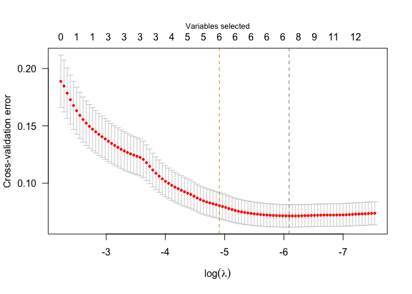

```r
plot(srl, plot_type = "cv")
```

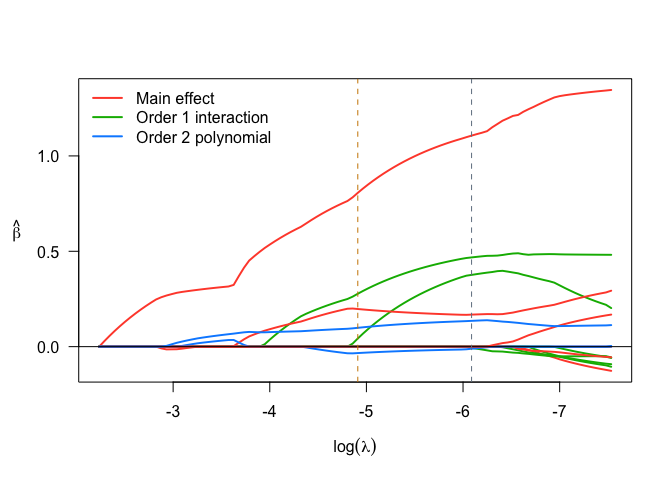

```r
plot(srl, plot_type = "path")
```

Importantly, since `sparseR` with a formula centers and scales the covariates prior to forming interactions, the coefficients should be interpreted this way (a 1-unit change in the covariate corresponds to a 1 SD change in the unit of the main effect, and parameters involving interactions must be interpreted at the mean value of involved covariates).

## 2.3 Using model matrix specification

Since the `sparseR` preprocessing has limits to its customizability, and often it will be of interest to create interactions that are centered at prespecified values (as opposed to their mean), it is also possible to feed in a matrix to `sparseR` that has already been preprocessed. The function also allows users to circumvent the recipes functionality and supply their own model matrix, composed of interactions and/or polynomials. This may be useful in cases where users wish to:

- specify their own missing data imputation methods,
- specify the intercept differently than a grand mean (avoid centering variables prior to making certain interactions of interest)
- scale variables differently

The key arguments for this purpose are to set `pre_process` to `FALSE`, and supply `model_matrix` and the outcome `y`. Users may also want to specify how the model matrix is specified in terms of polynomial order (the package requires a prefix, such as “poly_1”, or “poly_2” to denote polynomial terms of orders 1 and 2 respectively) and interaction seperator (by default, this is “\\:”, which is the default for `model.matrix`).

The code below creates a model matrix will all pairwise interactions, however as opposed to the formula, the numeric variables are not centered prior to forming the interactions, and the factor variable of species will be given a reference category (as opposed to a cell-means specification). Therefore, this method will lead to different results.

```r
X <- model.matrix(Sepal.Width ~ .*., data = iris)[,-1]
```

```r
set.seed(1)
srl2 <- sparseR(pre_process = FALSE, model_matrix = X, y = iris$Sepal.Width)
## Warning in ncvreg(X = X, y = y, ...): Maximum number of iterations reached
```

Since we have a warning about iterations, note that we can pass through arguments to `ncvreg` and fix this issue:

```r
set.seed(1)
srl2 <- sparseR(pre_process = FALSE, model_matrix = X, y = iris$Sepal.Width, max.iter = 1e6)
```

And we can use the same S3 methods to get more information about the SRL model:

```r
srl2
##
## Model summary @ min CV:
## -----------------------------------------------------
##   lasso-penalized linear regression with n=150, p=14
##   (At lambda=0.0005):
##     Nonzero coefficients: 8
##     Cross-validation error (deviance): 0.07
##     R-squared: 0.64
##     Signal-to-noise ratio: 1.77
##     Scale estimate (sigma): 0.261
##
##   SR information:
##              Vartype Total Selected Saturation Penalty
##          Main effect     5        3      0.600    2.24
##  Order 1 interaction     9        5      0.556    3.00
##
##
## Model summary @ CV1se:
## -----------------------------------------------------
##   lasso-penalized linear regression with n=150, p=14
##   (At lambda=0.0021):
##     Nonzero coefficients: 5
##     Cross-validation error (deviance): 0.08
##     R-squared: 0.59
##     Signal-to-noise ratio: 1.46
##     Scale estimate (sigma): 0.277
##
##   SR information:
##              Vartype Total Selected Saturation Penalty
##          Main effect     5        4      0.800    2.24
##  Order 1 interaction     9        1      0.111    3.00
summary(srl2, at = "cv1se")
## lasso-penalized linear regression with n=150, p=14
## At lambda=0.0021:
## -------------------------------------------------
##   Nonzero coefficients         :   5
##   Expected nonzero coefficients:   0.00
##   Average mfdr (5 features)    :   0.000
##
##                           Estimate      z    mfdr Selected
## Speciesvirginica           -1.1502 -25.15 < 1e-04        *
## Speciesversicolor          -1.0558 -23.10 < 1e-04        *
## Sepal.Length                0.4243  16.32 < 1e-04        *
## Petal.Width                 0.3390  12.06 < 1e-04        *
## Sepal.Length:Petal.Length  -0.0189 -11.68 < 1e-04        *
```

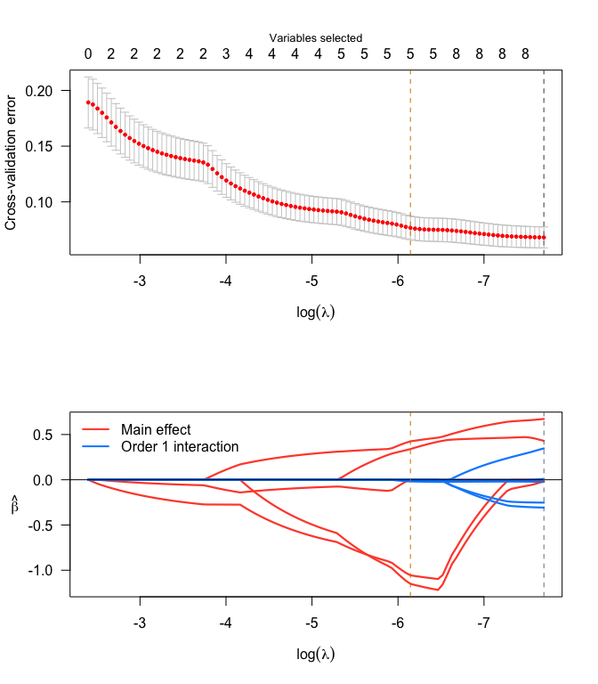

```r
plot(srl2)
```

Since we did not center/scale any of the variables prior to this fitting procedure, the interpretation of these coefficients should be on the original scale of the predictors, and the origin for the terms involved in interactions is 0, not at the mean of their constituent covariates.

Note also that there are fewer total covariates listed. This is because `model.matrix` uses reference cell dummy variables by default. Another way to do this without the reference category specification would be to pass pre-process options to `sparseR`, or to manually use `sparseR_prep` to create the model matrix.

```r
set.seed(1)
srl3 <- sparseR(Sepal.Width ~ ., data = iris, k = 1,
                pre_proc_opts = c("none"), max.iter = 1e6)
srl3
##
## Model summary @ min CV:
## -----------------------------------------------------
##   lasso-penalized linear regression with n=150, p=21
##   (At lambda=0.0006):
##     Nonzero coefficients: 6
##     Cross-validation error (deviance): 0.07
##     R-squared: 0.64
##     Signal-to-noise ratio: 1.80
##     Scale estimate (sigma): 0.259
##
##   SR information:
##              Vartype Total Selected Saturation Penalty
##          Main effect     6        2      0.333    2.45
##  Order 1 interaction    12        4      0.333    3.46
##   Order 2 polynomial     3        0      0.000    3.00
##
##
## Model summary @ CV1se:
## -----------------------------------------------------
##   lasso-penalized linear regression with n=150, p=21
##   (At lambda=0.0041):
##     Nonzero coefficients: 5
##     Cross-validation error (deviance): 0.08
##     R-squared: 0.59
##     Signal-to-noise ratio: 1.47
##     Scale estimate (sigma): 0.277
##
##   SR information:
##              Vartype Total Selected Saturation Penalty
##          Main effect     6        2      0.333    2.45
##  Order 1 interaction    12        2      0.167    3.46
##   Order 2 polynomial     3        1      0.333    3.00
summary(srl3, at = "cv1se")
## lasso-penalized linear regression with n=150, p=21
## At lambda=0.0041:
## -------------------------------------------------
##   Nonzero coefficients         :   5
##   Expected nonzero coefficients:   1.81
##   Average mfdr (5 features)    :   0.363
##
##                             Estimate      z    mfdr Selected
## Sepal.Length:Species_setosa  0.18862 21.079 < 1e-04        *
## Sepal.Length_poly_1          0.23292  9.248 < 1e-04        *
## Petal.Width_poly_2           0.06659  6.116 < 1e-04        *
## Species_virginica           -0.08945 -2.387 0.84724        *
## Petal.Width:Species_setosa   0.14950  1.542 0.96687        *
```

## 2.4 Centering to different values

In many cases with interactions, it makes sense to center variables to certain values (or rather, it does **not** make sense to center variables to their mean or to zero). Therefore we built some flexibility into `sparseR` and `sparseR_prep` in order to allow users to change these as the context dictates.

Each covariate’s centering location (in this case their minima) can be passed into `sparseR_prep` as follows:

```r
cc <- iris %>%
    select(Sepal.Length, Petal.Length, Petal.Width) %>%
    apply(2, min, na.rm = TRUE)


p1 <- sparseR_prep(Sepal.Width ~ ., iris, k = 0, extra_opts = list(centers = cc))
(c2min <- bake(p1, iris))
## # A tibble: 150 × 6
##    Sepal.Length Petal.Length Petal.Width Species_setosa Species_versicolor
##           <dbl>        <dbl>       <dbl>          <dbl>              <dbl>
##  1        0.966        0.227       0.131              1                  0
##  2        0.725        0.227       0.131              1                  0
##  3        0.483        0.170       0.131              1                  0
##  4        0.362        0.283       0.131              1                  0
##  5        0.845        0.227       0.131              1                  0
##  6        1.33         0.397       0.394              1                  0
##  7        0.362        0.227       0.262              1                  0
##  8        0.845        0.283       0.131              1                  0
##  9        0.121        0.227       0.131              1                  0
## 10        0.725        0.283       0                  1                  0
## # ℹ 140 more rows
## # ℹ 1 more variable: Species_virginica <dbl>
summary(c2min)
##   Sepal.Length     Petal.Length     Petal.Width     Species_setosa
##  Min.   :0.0000   Min.   :0.0000   Min.   :0.0000   Min.   :0.0000
##  1st Qu.:0.9661   1st Qu.:0.3399   1st Qu.:0.2624   1st Qu.:0.0000
##  Median :1.8115   Median :1.8977   Median :1.5743   Median :0.0000
##  Mean   :1.8638   Mean   :1.5623   Mean   :1.4422   Mean   :0.3333
##  3rd Qu.:2.5360   3rd Qu.:2.3226   3rd Qu.:2.2303   3rd Qu.:1.0000
##  Max.   :4.3475   Max.   :3.3422   Max.   :3.1486   Max.   :1.0000
##  Species_versicolor Species_virginica
##  Min.   :0.0000     Min.   :0.0000
##  1st Qu.:0.0000     1st Qu.:0.0000
##  Median :0.0000     Median :0.0000
##  Mean   :0.3333     Mean   :0.3333
##  3rd Qu.:1.0000     3rd Qu.:1.0000
##  Max.   :1.0000     Max.   :1.0000
```

Or directly into `sparseR`:

```r
srl_centered2min <- sparseR(Sepal.Width ~ ., iris, extra_opts = list(centers = cc), seed = 1)
```

Or, a function can be passed to evaluate the location for each covariate:

```r
p2 <- sparseR_prep(Sepal.Width ~ ., iris, k = 0, extra_opts = list(center_fn = function(x, ...) min(x, ...)))
(c2min2 <- bake(p2, iris))
## # A tibble: 150 × 6
##    Sepal.Length Petal.Length Petal.Width Species_setosa Species_versicolor
##           <dbl>        <dbl>       <dbl>          <dbl>              <dbl>
##  1        0.966        0.227       0.131              1                  0
##  2        0.725        0.227       0.131              1                  0
##  3        0.483        0.170       0.131              1                  0
##  4        0.362        0.283       0.131              1                  0
##  5        0.845        0.227       0.131              1                  0
##  6        1.33         0.397       0.394              1                  0
##  7        0.362        0.227       0.262              1                  0
##  8        0.845        0.283       0.131              1                  0
##  9        0.121        0.227       0.131              1                  0
## 10        0.725        0.283       0                  1                  0
## # ℹ 140 more rows
## # ℹ 1 more variable: Species_virginica <dbl>
identical(c2min2, c2min)
## [1] TRUE
```

## 2.5 Plotting the model

Interactions are notoriously difficult to understand and to communicate, and visualizations can often be helpful. The `sparseR` package has some limited functionality for plotting the results from these fits, using the `visreg` package as a rough guide.

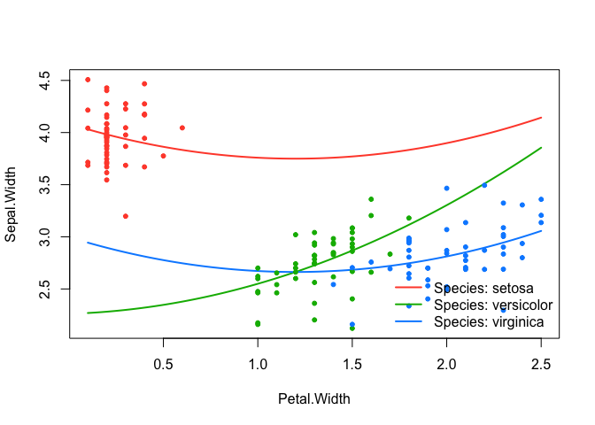

```r
effect_plot(srl, "Petal.Width", by = "Species")
```

Notice how this changes if the covariates are centered to their minima instead:

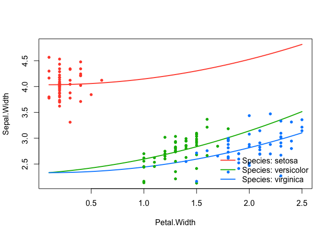

```r
effect_plot(srl_centered2min, "Petal.Width", by = "Species")
```

It’s clear that the model itself can change quite a bit depending on the center location utilized prior to building the interactions. Unfortunately, optimizing the center location for each covariate is a difficult, p-dimensional problem (set in the context of another difficult optimization problem of regularized regression with multiple tuning parameters).

The `sparseR` package will allow users to compare certain choices in terms of their cross-validated error, which is a decent starting point. The plot below shows how the “centered to zero” model has *slightly* lower cross-validated error than the best mean-centered model and the best minimum-centered model.

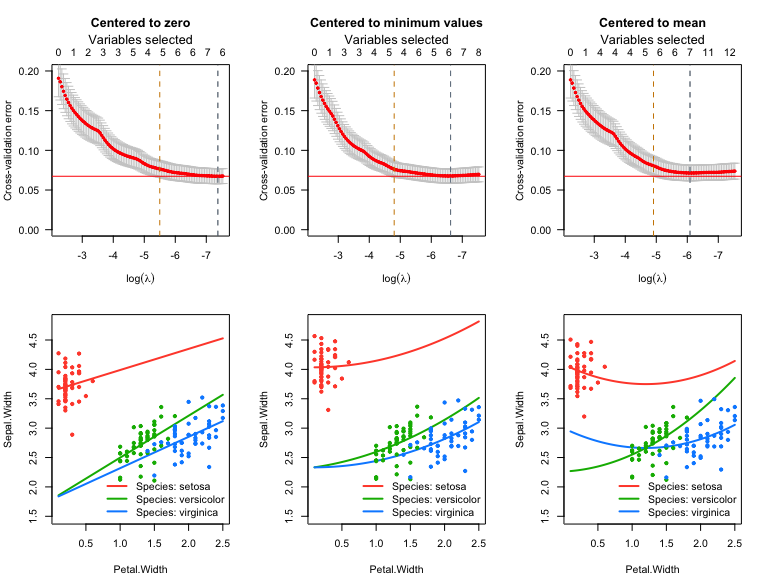

```r
plot(srl3, plot_type = "cv", ylim = c(0,.2))
abline(h = min(srl3$fit$cve), col = "red")
plot(srl_centered2min, plot_type = "cv", ylim = c(0,.2))
abline(h = min(srl3$fit$cve), col = "red")
plot(srl, plot_type = "cv", ylim = c(0,.2))
abline(h = min(srl3$fit$cve), col = "red")

effect_plot(srl3, "Petal.Width", by = "Species",
            plot.args = list(ylim = c(1.5, 4.8)))
effect_plot(srl_centered2min, "Petal.Width", by = "Species",
            plot.args = list(ylim = c(1.5, 4.8)))
effect_plot(srl, "Petal.Width", by = "Species",
            plot.args = list(ylim = c(1.5, 4.8)))
```

Though these models look substantially different, it’s worth noting that the predictions obtained from the three models are very close to one another (since the models look similar in the neighborhood of existing data):

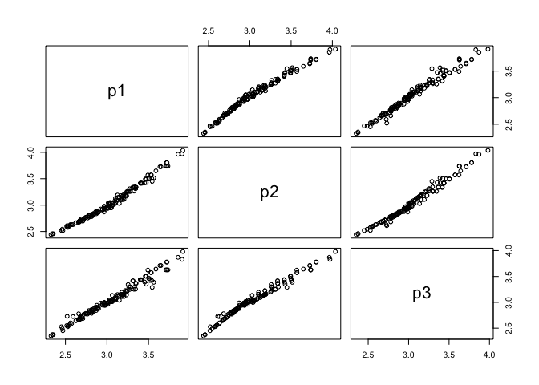

```r
p1 <- predict(srl3, at = "cvmin")
p2 <- predict(srl_centered2min, at = "cvmin")
p3 <- predict(srl, at = "cvmin")

cor(cbind(p1, p2 ,p3))
##           p1        p2        p3
## p1 1.0000000 0.9903513 0.9873102
## p2 0.9903513 1.0000000 0.9898124
## p3 0.9873102 0.9898124 1.0000000
pairs(cbind(p1, p2 ,p3))
```

At the CV1se lambda value, there is slightly less agreement in these predictions:

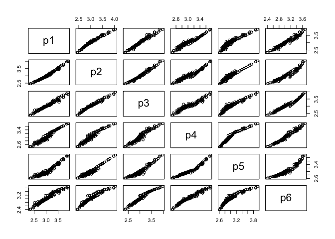

[figure not shown]

```r
# At CV1se
p4 <- predict(srl3, at = "cv1se")
p5 <- predict(srl_centered2min, at = "cv1se")
p6 <- predict(srl, at = "cv1se")

cor(cbind(p1, p2 ,p3, p4,p5,p6))
##           p1        p2        p3        p4        p5        p6
## p1 1.0000000 0.9903513 0.9873102 0.9781221 0.9586728 0.9752579
## p2 0.9903513 1.0000000 0.9898124 0.9714612 0.9784280 0.9627639
## p3 0.9873102 0.9898124 1.0000000 0.9706405 0.9671849 0.9821402
## p4 0.9781221 0.9714612 0.9706405 1.0000000 0.9709760 0.9845977
## p5 0.9586728 0.9784280 0.9671849 0.9709760 1.0000000 0.9504649
## p6 0.9752579 0.9627639 0.9821402 0.9845977 0.9504649 1.0000000
pairs(cbind(p1, p2 ,p3, p4,p5,p6))
```

```r
effect_plot(srl3, "Petal.Width", by = "Species", at = "cv1se")
effect_plot(srl_centered2min, "Petal.Width", by = "Species", at = "cv1se")
effect_plot(srl, "Petal.Width", by = "Species", at = "cv1se")
```

## 2.6 Using stepwise RBIC

RBIC, or *Ranked-sparsity Bayesian Information Criterion*, is a ranked sparsity model selection criterion that will correctly penalize interactions (higher than main effects). The benefit of using a stepwise approach informed by RBIC is that there is no shrinkage, and it thus doesn’t matter whether or not (or where) the covariates are centered (usually). The exceptions here occur when the stepwise process is not sequential/hierarchical (i.e. main effects first, then interactions of the “active” main effects, etc.).

Inference on the parameters is still i) difficult because one must account for post-selection inference, and ii) affected by where and whether the covariates are centered. However, the lines themselves will not be affected by centering status.

We can see this in the examples below:

```r
## Centered model
(rbic1 <- sparseRBIC_step(Sepal.Width ~ ., iris, pre_proc_opts = c("center", "scale")))
## Note: sparseRBIC_step is currently experimental and may not behave as expected.
##
## Call:  glm(formula = y ~ Species_setosa + Sepal.Length + Petal.Width +
##     Species_versicolor + Petal.Length + `Sepal.Length:Species_setosa`,
##     family = family, data = X)
##
## Coefficients:
##                   (Intercept)                 Species_setosa
##                       2.40062                        2.14130
##                  Sepal.Length                    Petal.Width
##                       0.16506                        0.44726
##            Species_versicolor                   Petal.Length
##                       0.29340                       -0.05916
## `Sepal.Length:Species_setosa`
##                       0.45943
##
## Degrees of Freedom: 149 Total (i.e. Null);  143 Residual
## Null Deviance:       28.31
## Residual Deviance: 8.999     AIC: 19.65

# Non-centered model
(rbic2 <- sparseRBIC_step(Sepal.Width ~ ., iris, pre_proc_opts = c("scale")))
## Note: sparseRBIC_step is currently experimental and may not behave as expected.
##
## Call:  glm(formula = y ~ Species_setosa + Sepal.Length + Petal.Width +
##     Species_virginica + Petal.Length + `Sepal.Length:Species_setosa`,
##     family = family, data = X)
##
## Coefficients:
##                   (Intercept)                 Species_setosa
##                       0.95150                       -1.39414
##                  Sepal.Length                    Petal.Width
##                       0.16506                        0.44726
##             Species_virginica                   Petal.Length
##                      -0.29340                       -0.05916
## `Sepal.Length:Species_setosa`
##                       0.45943
##
## Degrees of Freedom: 149 Total (i.e. Null);  143 Residual
## Null Deviance:       28.31
## Residual Deviance: 8.999     AIC: 19.65
```

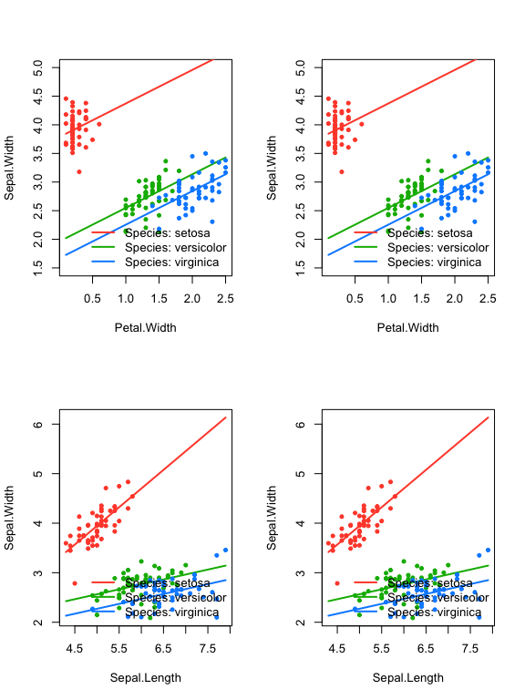

```r
effect_plot(rbic1, "Petal.Width", by = "Species", plot.args = list(ylim = c(1.5, 5)))
effect_plot(rbic2, "Petal.Width", by = "Species", plot.args = list(ylim = c(1.5, 5)))
effect_plot(rbic1, "Sepal.Length", by = "Species")
effect_plot(rbic2, "Sepal.Length", by = "Species")
```

Again similar S3 methods are available (note how inference does change for certain parameters based on the centering status). A message is produced because these p-values do not account for post-selection inference.

```r
summary(rbic1)
## P-values have **not** been corrected for multiple comparisons
## Consider sparseRBIC_sampsplit() or sparseRBIC_bootstrap()
##
## Call:
## glm(formula = y ~ Species_setosa + Sepal.Length + Petal.Width +
##     Species_versicolor + Petal.Length + `Sepal.Length:Species_setosa`,
##     family = family, data = X)
##
## Coefficients:
##                               Estimate Std. Error t value Pr(>|t|)
## (Intercept)                    2.40062    0.12025  19.964  < 2e-16 ***
## Species_setosa                 2.14130    0.30584   7.001 9.10e-11 ***
## Sepal.Length                   0.16506    0.06017   2.743  0.00687 **
## Petal.Width                    0.44726    0.08833   5.064 1.25e-06 ***
## Species_versicolor             0.29340    0.09839   2.982  0.00337 **
## Petal.Length                  -0.05916    0.15021  -0.394  0.69428
## `Sepal.Length:Species_setosa`  0.45943    0.09997   4.596 9.40e-06 ***
## ---
## Signif. codes:  0 '***' 0.001 '**' 0.01 '*' 0.05 '.' 0.1 ' ' 1
##
## (Dispersion parameter for gaussian family taken to be 0.06292687)
##
##     Null deviance: 28.3069  on 149  degrees of freedom
## Residual deviance:  8.9985  on 143  degrees of freedom
## AIC: 19.646
##
## Number of Fisher Scoring iterations: 2
summary(rbic2)
## P-values have **not** been corrected for multiple comparisons
## Consider sparseRBIC_sampsplit() or sparseRBIC_bootstrap()
##
## Call:
## glm(formula = y ~ Species_setosa + Sepal.Length + Petal.Width +
##     Species_virginica + Petal.Length + `Sepal.Length:Species_setosa`,
##     family = family, data = X)
##
## Coefficients:
##                               Estimate Std. Error t value Pr(>|t|)
## (Intercept)                    0.95150    0.26641   3.572 0.000484 ***
## Species_setosa                -1.39414    0.58460  -2.385 0.018401 *
## Sepal.Length                   0.16506    0.06017   2.743 0.006865 **
## Petal.Width                    0.44726    0.08833   5.064 1.25e-06 ***
## Species_virginica             -0.29340    0.09839  -2.982 0.003367 **
## Petal.Length                  -0.05916    0.15021  -0.394 0.694277
## `Sepal.Length:Species_setosa`  0.45943    0.09997   4.596 9.40e-06 ***
## ---
## Signif. codes:  0 '***' 0.001 '**' 0.01 '*' 0.05 '.' 0.1 ' ' 1
##
## (Dispersion parameter for gaussian family taken to be 0.06292687)
##
##     Null deviance: 28.3069  on 149  degrees of freedom
## Residual deviance:  8.9985  on 143  degrees of freedom
## AIC: 19.646
##
## Number of Fisher Scoring iterations: 2
```

Alternatively, sample splitting can be utilized to achieve valid inference. This method divides the data into two samples of equal size, uses the first sample to select the model, and the second one to fit and achieve valid (though potentially low-power) inference. Coefficients which are not selected are bestowed a p-value of 1.

```r
s1 <- sparseRBIC_sampsplit(rbic1)
```

```
## Note: sparseRBIC_sampsplit is currently experimental and may not behave as expected.
## Warning: `progress_estimated()` was deprecated in dplyr 1.0.0.
## ℹ The deprecated feature was likely used in the sparseR package.
##   Please report the issue to the authors.
```

| Coefficient | Median_p | Mean_p | Gmean_p | % selected |
| --- | --- | --- | --- | --- |
| (Intercept) | 0.00000 | 0.00000 | 0.00000 | 100 |
| Species_setosa | 0.00000 | 0.00000 | 0.00000 | 100 |
| Sepal.Length | 0.00003 | 0.11104 | 0.00007 | 90 |
| Sepal.Length:Species_setosa | 0.00870 | 0.30440 | 0.01235 | 70 |
| Petal.Width | 0.50777 | 0.50342 | 0.05012 | 50 |
| Species_versicolor | 1.00000 | 0.70857 | 0.24735 | 30 |
| Petal.Length | 1.00000 | 0.96673 | 0.96036 | 10 |
| Species_virginica | 1.00000 | 0.90080 | 0.61697 | 10 |

```r
s2 <- sparseRBIC_sampsplit(rbic2)
```

```
## Note: sparseRBIC_sampsplit is currently experimental and may not behave as expected.
```

| Coefficient | Median_p | Mean_p | Gmean_p | % selected |
| --- | --- | --- | --- | --- |
| (Intercept) | 0.04286 | 0.12971 | 0.01964 | 100 |
| Species_setosa | 0.09819 | 0.14157 | 0.00595 | 100 |
| Sepal.Length | 0.00063 | 0.00644 | 0.00008 | 100 |
| Sepal.Length:Species_setosa | 0.01678 | 0.20926 | 0.00805 | 80 |
| Petal.Width | 0.06679 | 0.41570 | 0.06695 | 60 |
| Species_virginica | 1.00000 | 0.64516 | 0.41337 | 40 |
| Petal.Width:Species_setosa | 1.00000 | 0.92315 | 0.90718 | 20 |
| Species_versicolor | 1.00000 | 0.90350 | 0.71508 | 10 |
| Petal.Length | 1.00000 | 0.98405 | 0.98277 | 10 |
| Sepal.Length:Petal.Length | 1.00000 | 0.93700 | 0.90536 | 10 |
| Sepal.Length:Petal.Width | 1.00000 | 0.90141 | 0.65295 | 10 |

Additionally, inferences based on bootstrapped samples of the data are available via the `sparseRBIC_bootstrap` function, which stores p-values for each coefficient after model selection has been performed. If a coefficient has not been selected, the p-value is set to one for that bootstrap iteration, so when the “mean” p-value is calculated across bootstraps, the underestimation of the p-value due to model selection is attenuated, as the estimate gets “pulled up” by the 1’s in the vector. Since this may be a conservative approach, we also display the “geometric” mean which is a measure of central tendency less sensitive to skew (which many p-values will be highly right skewed). More research must be done on these techniques to ensure adequate coverage properties, but given a high enough number of bootstrap samples they should both be more conservative than the naive, “pretend model selection never took place” approach. The downside here is that depending on the size of the data and the number of variables, this could take quite some time.

Note that the mean p-value across bootstraps is bounded to be greater than 1-P(selected). In some sense, this makes sense, as if a variable has a low probability of being selected, then that variable should have a higher adjusted p-value. However, for variables whose effects will be highly related (i.e. an interaction and a constituent main effect), this may be too conservative.

```r
set.seed(1)
## Centered model
b1 <- sparseRBIC_bootstrap(rbic1)
```

| Coefficient | Mean_p | Gmean_p | % selected |
| --- | --- | --- | --- |
| (Intercept) | 0.00000 | 0.00000 | 100 |
| Species_setosa | 0.00011 | 0.00000 | 100 |
| Sepal.Length | 0.00293 | 0.00000 | 100 |
| Sepal.Length:Species_setosa | 0.20011 | 0.00002 | 80 |
| Petal.Width | 0.50000 | 0.00008 | 50 |
| Species_versicolor | 0.70010 | 0.07691 | 30 |
| Petal.Length | 0.81087 | 0.54467 | 20 |
| Sepal.Length:Petal.Width | 0.90000 | 0.32270 | 10 |
| Sepal.Length:Species_versicolor | 0.90222 | 0.68331 | 10 |
| Species_virginica | 0.90000 | 0.21139 | 10 |
| Petal.Width:Species_setosa | 0.90182 | 0.66977 | 10 |
| Sepal.Length:Petal.Length | 0.90000 | 0.22450 | 10 |

```r
set.seed(1)
## Uncentered model
b2 <- sparseRBIC_bootstrap(rbic2)
```

```
## Note: sparseRBIC_bootstrap is currently experimental and may not behave as expected.
```

| Coefficient | Mean_p | Gmean_p | % selected |
| --- | --- | --- | --- |
| (Intercept) | 0.16411 | 0.00016 | 100 |
| Species_setosa | 0.08507 | 0.00002 | 100 |
| Sepal.Length | 0.00293 | 0.00000 | 100 |
| Sepal.Length:Species_setosa | 0.20011 | 0.00002 | 80 |
| Petal.Width | 0.50000 | 0.00017 | 50 |
| Species_versicolor | 0.60079 | 0.02124 | 40 |
| Petal.Length | 0.80312 | 0.38407 | 20 |
| Sepal.Length:Petal.Width | 0.90000 | 0.32270 | 10 |
| Sepal.Length:Species_versicolor | 0.90222 | 0.68331 | 10 |
| Petal.Width:Species_setosa | 0.90182 | 0.66977 | 10 |
| Sepal.Length:Petal.Length | 0.90000 | 0.22450 | 10 |

This section is still under development.

# 3 Use case: lung data

## 3.1 Data set description

As a more realistic example, we take a data set that is often used to train models that can predict lung cancer status. It has 1027 observations and 14 covariates, including urban/rural, age, years of school, smoking years, number of children, etc.

First, let’s look at the data a little:

```r
data("irlcs_radon_syn")
summary(irlcs_radon_syn)
##        ID         CITY       YRSHOME          AGE        CASE    SCHOOL
##  Min.   :   1.0   0:246   Min.   :20.0   Min.   :44.16   0:632   1: 92
##  1st Qu.: 260.5   1:781   1st Qu.:25.0   1st Qu.:61.38   1:395   2:506
##  Median : 492.0           Median :31.0   Median :67.84           3:293
##  Mean   : 505.2           Mean   :33.1   Mean   :67.45           4:106
##  3rd Qu.: 761.0           3rd Qu.:39.0   3rd Qu.:73.82           5: 30
##  Max.   :1026.0           Max.   :75.0   Max.   :84.80
##
##      SMKYRS         CHILDREN           PYR            PYRRATE
##  Min.   : 0.00   Min.   : 0.000   Min.   :  0.00   Min.   :0.00000
##  1st Qu.: 0.00   1st Qu.: 2.000   1st Qu.:  0.00   1st Qu.:0.00000
##  Median :13.00   Median : 3.000   Median :  3.60   Median :0.05368
##  Mean   :20.58   Mean   : 3.065   Mean   : 19.31   Mean   :0.31745
##  3rd Qu.:41.00   3rd Qu.: 4.000   3rd Qu.: 35.07   3rd Qu.:0.58024
##  Max.   :64.00   Max.   :13.000   Max.   :138.45   Max.   :2.55702
##
##     SMKQUIT            BMI            WLM20        PRELUNG SMKEVER SMKCUR
##  Min.   : 0.000   Min.   :16.64   Min.   : 2.176   0:692   0:476   0:705
##  1st Qu.: 0.000   1st Qu.:21.79   1st Qu.: 5.902   1:335   1:551   1:322
##  Median : 0.000   Median :23.78   Median : 8.683
##  Mean   : 4.733   Mean   :24.60   Mean   :10.914
##  3rd Qu.: 3.325   3rd Qu.:27.40   3rd Qu.:13.246
##  Max.   :57.355   Max.   :41.60   Max.   :77.457
##                   NA's   :51
```

Note:

```r
irlcs_radon_syn <- select(irlcs_radon_syn, -ID)
```

At this point, we will split the data into a test and training set.

```r
set.seed(13)

N <- nrow(irlcs_radon_syn)
trainIDX <- sample(1:N, N * .75)
train <- irlcs_radon_syn[trainIDX,]
test <- irlcs_radon_syn[-trainIDX,]
```